# Labb4

```python
!jupyter nbconvert --to html "/content/Labb4.ipynb"
```

```
[NbConvertApp] Converting notebook /content/Labb4.ipynb to html
[NbConvertApp] WARNING | Alternative text is missing on 10 image(s).
[NbConvertApp] Writing 2601325 bytes to /content/Labb4.html
```

### Computer Assignment 4 - Portfolio Selection

```python
import numpy as np
import pandas as pd
import matplotlib.pyplot as plt
import cvxpy as cp
```

## Exercise 1

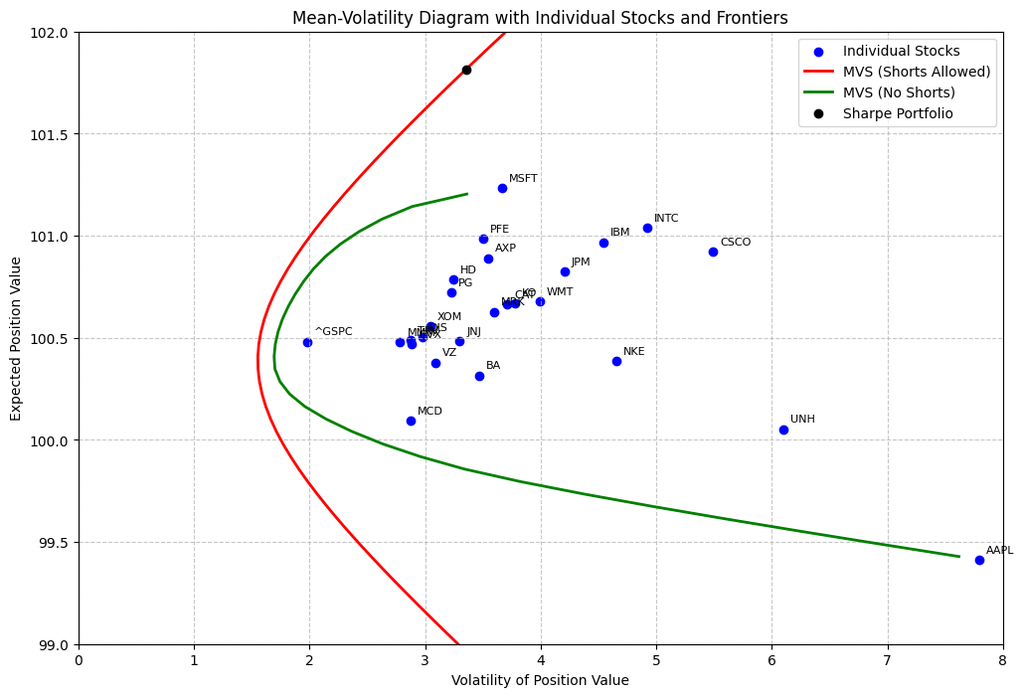

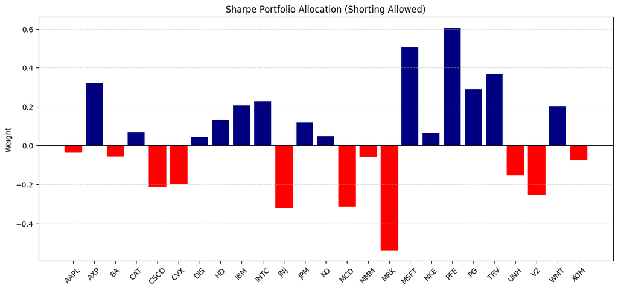

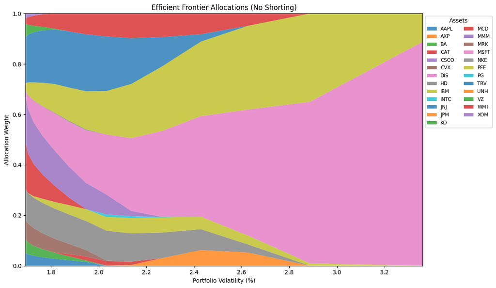

```
Stock        Weight     Weight %
--------------------------------
AAPL       0.051954        5.20%
BA         0.053469        5.35%
CVX        0.078856        7.89%
HD         0.120680       12.07%
MCD        0.185815       18.58%
MMM        0.186227       18.62%
MSFT       0.016535        1.65%
NKE        0.002288        0.23%
PFE        0.028059        2.81%
TRV        0.181610       18.16%
VZ         0.053618        5.36%
WMT        0.021059        2.11%
XOM        0.019829        1.98%
--------------------------------
Total      1.000000      100.00%
```

```python
data = pd.read_csv('Dow_SP9624_weekly.csv', sep=";")
stock_names = ["AAPL", "AXP", "BA", "CAT", "CSCO", "CVX", "DIS", "HD", "IBM",
               "INTC", "JNJ", "JPM", "KO", "MCD", "MMM", "MRK", "MSFT",
               "NKE", "PFE", "PG", "TRV", "UNH", "VZ", "WMT", "XOM", "^GSPC"]

# 1a)---------------------------------------------------------------------------

stocks = data[stock_names]
subset_returns = (stocks / stocks.shift(1)).dropna().iloc[:100]

means = subset_returns.mean()
stds = subset_returns.std()

expected_values = 100 * means
value_volatilities = 100 * stds

# 1b)---------------------------------------------------------------------------

risky_assets = subset_returns.drop(columns=['^GSPC'], errors='ignore')
asset_names = risky_assets.columns
num_assets = len(asset_names)

mu = risky_assets.mean().values
Sigma = risky_assets.cov().values

target_values = np.linspace(99, 102, 50)
target_returns = target_values / 100

mvs_shorts_vol = []
mvs_no_shorts_vol = []
weights_no_shorts = []
# ---------------------------------------------------------

for tr in target_returns:
    w = cp.Variable(num_assets)
    risk = cp.quad_form(w, Sigma)
    objective = cp.Minimize(risk)

    constraints = [cp.sum(w) == 1, w @ mu == tr]
    prob_shorts = cp.Problem(objective, constraints)
    try:
        prob_shorts.solve()
        if prob_shorts.status == cp.OPTIMAL:
            vol = np.sqrt(prob_shorts.value) * 100
            mvs_shorts_vol.append(vol)
        else:
            mvs_shorts_vol.append(np.nan)
    except:
        mvs_shorts_vol.append(np.nan)

    constraints_no_short = constraints + [w >= 0]
    prob_no_shorts = cp.Problem(objective, constraints_no_short)
    try:
        prob_no_shorts.solve()
        if prob_no_shorts.status == cp.OPTIMAL:
            vol = np.sqrt(prob_no_shorts.value) * 100
            mvs_no_shorts_vol.append(vol)
            clean_w = w.value
            clean_w[clean_w < 1e-5] = 0
            weights_no_shorts.append(clean_w)
        else:
            mvs_no_shorts_vol.append(np.nan)
            weights_no_shorts.append(np.zeros(num_assets))
    except:
        mvs_no_shorts_vol.append(np.nan)
        weights_no_shorts.append(np.zeros(num_assets))

vol_array = np.array(mvs_no_shorts_vol)
weights_array = np.array(weights_no_shorts)
valid_mask = ~np.isnan(vol_array)

vol_valid = vol_array[valid_mask]
weights_valid = weights_array[valid_mask]

# Find minimum variance portfolio
mvp_idx = np.argmin(vol_valid)
mvp_weights = weights_valid[mvp_idx]
mvp_volatility = vol_valid[mvp_idx]

Rf = 1
inv_Sigma = np.linalg.inv(Sigma)
excess_mu = mu - Rf
Z = inv_Sigma @ excess_mu
w_sharpe = Z / np.sum(Z)
mu_sharpe = w_sharpe @ mu
var_sharpe = w_sharpe @ Sigma @ w_sharpe
std_sharpe = np.sqrt(var_sharpe)
exp_val_sharpe = 100 * mu_sharpe
vol_val_sharpe = 100 * std_sharpe


# """--- Plotting 1a&B) -----------------------------------------------------------

plt.figure(figsize=(12, 8))
plt.scatter(value_volatilities, expected_values, color='blue', marker='o', label='Individual Stocks')
for stock_name, x, y in zip(subset_returns.columns, value_volatilities, expected_values):
    plt.annotate(stock_name, (x, y), xytext=(5, 5), textcoords='offset points', fontsize=8)

plt.plot(mvs_shorts_vol, target_values, 'r-', linewidth=2, label='MVS (Shorts Allowed)')
plt.plot(mvs_no_shorts_vol, target_values, 'g-', linewidth=2, label='MVS (No Shorts)')

plt.scatter(vol_val_sharpe, exp_val_sharpe, color='black', label='Sharpe Portfolio', zorder=5)

plt.title('Mean-Volatility Diagram with Individual Stocks and Frontiers')
plt.xlabel('Volatility of Position Value')
plt.ylabel('Expected Position Value')
plt.grid(True, linestyle='--', alpha=0.7)
plt.legend()
plt.xlim(0, 8)
plt.ylim(99, 102)

# 1c)& d)---------------------------------------------------------------------------

plt.figure(figsize=(14, 6))
bars = plt.bar(asset_names, w_sharpe, color='navy')

plt.title('Sharpe Portfolio Allocation (Shorting Allowed)')
plt.ylabel('Weight')
plt.axhline(0, color='black', linewidth=1)
plt.grid(axis='y', linestyle='--', alpha=0.5)
plt.xticks(rotation=45)

for bar, w in zip(bars, w_sharpe):
    if w < 0:
        bar.set_color('red')


# 1e) Area Plot of Efficient Frontier Allocations (No Shorts) --------------------


vol_data = np.array(mvs_no_shorts_vol)
weights_data = np.array(weights_no_shorts)
valid_mask = ~np.isnan(vol_data)
vol_data = vol_data[valid_mask]
weights_data = weights_data[valid_mask]

min_vol_idx = np.argmin(vol_data)
eff_vol = vol_data[min_vol_idx:]
eff_weights = weights_data[min_vol_idx:]
eff_weights_T = eff_weights.T

plt.figure(figsize=(12, 7))
plt.stackplot(eff_vol, eff_weights_T, labels=asset_names, alpha=0.8)

plt.title('Efficient Frontier Allocations (No Shorting)')
plt.xlabel('Portfolio Volatility (%)')
plt.ylabel('Allocation Weight')
plt.margins(0, 0)
plt.legend(loc='upper left', bbox_to_anchor=(1, 1), ncol=2, fontsize='small', title="Assets")
plt.tight_layout()
plt.show()

# Information to answer the Discussion question
print(f"{'Stock':<8} {'Weight':>10} {'Weight %':>12}")
print("-"*32)

for stock, weight in zip(asset_names, mvp_weights):
    if weight > 0.001:  # Only show meaningful allocations
        print(f"{stock:<8} {weight:>10.6f} {weight*100:>11.2f}%")

print("-"*32)
print(f"{'Total':<8} {np.sum(mvp_weights):>10.6f} {np.sum(mvp_weights)*100:>11.2f}%")
```

### Discussion Task 1:

No Apple did not look like a good investment since it was the riskiest stock with the lowest epected return. Above are the stocks from the "No Short Minimmum Variance portfolio" listed.

## Exercise 2

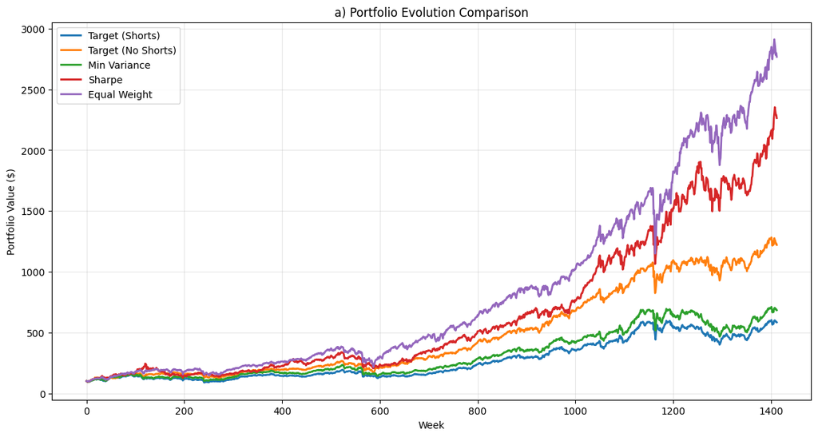

```
 b) Portfolio values every 100 weeks
======================================================================================================================================================
Week             Target (Shorts)    Target (No Shorts)          Min Variance                Sharpe          Equal Weight
------------------------------------------------------------------------------------------------------------------------------------------------------
0                         100.00                100.00                100.00                100.00                100.00
100                       139.60                154.93                145.45                170.33                175.93
200                       116.51                156.69                132.72                145.69                179.18
300                       116.77                150.67                134.19                160.63                200.16
400                       143.79                195.10                168.83                224.34                261.43
500                       168.89                239.79                201.44                309.72                369.30
600                       133.75                218.99                154.52                238.21                304.30
700                       162.00                300.73                195.07                349.88                479.93
800                       238.51                420.36                285.87                510.50                644.02
900                       291.96                522.31                349.47                650.32                857.27
1000                      355.99                678.38                422.61                761.43               1020.57
1100                      425.38                851.86                494.25               1089.23               1350.97
1200                      537.22               1095.01                629.91               1524.43               1825.20
1300                      447.61               1037.80                509.05               1759.02               2119.60
1400                      595.75               1271.62                703.28               2150.94               2818.91

c) Performance Metrics
======================================================================================================================================================
Metric                          Target (Shorts)    Target (No Shorts)          Min Variance                Sharpe          Equal Weight
------------------------------------------------------------------------------------------------------------------------------------------------------
Final Value                            583.8431             1220.6996              683.6129             2264.2508             2768.1376
Annual Return                            0.0772                0.1033                0.0833                0.1324                0.1371
Annual Volatility                        0.1555                0.1479                0.1570                0.1860                0.1709
Sharpe Ratio                             0.4966                0.6985                0.5306                0.7120                0.8024
Alpha vs S&P500                         -0.0060                0.0201                0.0001                0.0492                0.0539
Max Drawdown                            -0.4320               -0.3517               -0.3914               -0.4769               -0.4377
Avg ENC                                  3.0836                5.9074                3.1301                4.1297               25.0000
```

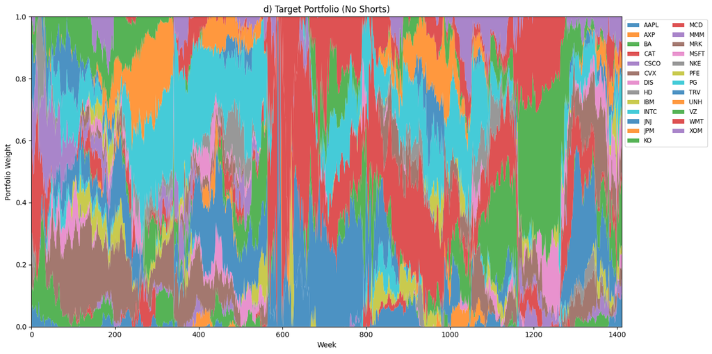

```python
data = pd.read_csv('Dow_SP9624_weekly.csv', sep=";")
stock_names = ["AAPL", "AXP", "BA", "CAT", "CSCO", "CVX", "DIS", "HD", "IBM",
               "INTC", "JNJ", "JPM", "KO", "MCD", "MMM", "MRK", "MSFT",
               "NKE", "PFE", "PG", "TRV", "UNH", "VZ", "WMT", "XOM"]

stocks = data[stock_names]
sp500 = data['^GSPC']
gross_returns = (stocks / stocks.shift(1)).dropna()
sp500_returns = (sp500 / sp500.shift(1)).dropna()
num_assets = len(stock_names)

# Optimization functions
def optimize_target_portfolio(mu, Sigma, target_return, allow_shorts=True):
    w = cp.Variable(num_assets)
    risk = cp.quad_form(w, Sigma)
    objective = cp.Minimize(risk)
    constraints = [cp.sum(w) == 1, w @ mu == target_return]
    if not allow_shorts:
        constraints.append(w >= 0)
    prob = cp.Problem(objective, constraints)
    prob.solve()
    return w.value if prob.status == cp.OPTIMAL else None

def optimize_minimum_variance(Sigma, allow_shorts=True):
    w = cp.Variable(num_assets)
    risk = cp.quad_form(w, Sigma)
    objective = cp.Minimize(risk)
    constraints = [cp.sum(w) == 1]
    if not allow_shorts:
        constraints.append(w >= 0)
    prob = cp.Problem(objective, constraints)
    prob.solve()
    return w.value if prob.status == cp.OPTIMAL else None


def optimize_sharpe_portfolio(mu, Sigma):

    Rf = 1.0
    excess_mu = mu - Rf

    if np.all(excess_mu <= 0):
        return optimize_minimum_variance(Sigma, allow_shorts=False)

    y = cp.Variable(num_assets)
    objective = cp.Minimize(cp.quad_form(y, Sigma))
    constraints = [excess_mu @ y == 1, y >= 0]
    prob = cp.Problem(objective, constraints)
    prob.solve()

    if prob.status == cp.OPTIMAL:
        y_opt = y.value
        if np.sum(y_opt) > 0:
            weights = y_opt / np.sum(y_opt)
            return weights
    else:
        return optimize_minimum_variance(Sigma, allow_shorts=False)


def equal_weight_portfolio(num_assets):
    return np.ones(num_assets) / num_assets

def handle_failure(mu, target_return, allow_shorts=True):
    weights = np.zeros(num_assets)
    best_idx = np.argmax(mu)
    worst_idx = np.argmin(mu)
    mu_best = mu[best_idx]
    mu_worst = mu[worst_idx]

    if abs(mu_best - mu_worst) < 1e-10:
        return np.ones(num_assets) / num_assets

    if target_return < mu_worst:
        if allow_shorts:
            w_worst = (target_return - mu_best) / (mu_worst - mu_best)
            w_best = 1 - w_worst
            weights[worst_idx] = w_worst
            weights[best_idx] = w_best
        else:
            weights[worst_idx] = 1.0
    elif target_return > mu_best:
        if allow_shorts:
            w_best = (target_return - mu_worst) / (mu_best - mu_worst)
            w_worst = 1 - w_best
            weights[best_idx] = w_best
            weights[worst_idx] = w_worst
        else:
            weights[best_idx] = 1.0
    else:
        alpha = (target_return - mu_worst) / (mu_best - mu_worst)
        weights[best_idx] = alpha
        weights[worst_idx] = 1 - alpha

    return weights

window = 100
target_return = 1.0025

portfolios = {
    'Target (Shorts)': [100],
    'Target (No Shorts)': [100],
    'Min Variance': [100],
    'Sharpe': [100],
    'Equal Weight': [100]
}

weights_history = {
    'Target (Shorts)': [],
    'Target (No Shorts)': [],
    'Min Variance': [],
    'Sharpe': [],
    'Equal Weight': []
}

for t in range(window, len(gross_returns)):
    returns_window = gross_returns.iloc[t-window:t]
    mu = returns_window.mean().values
    Sigma = returns_window.cov().values
    actual_returns = gross_returns.iloc[t].values

    # Target porftolio with shorting
    weights = optimize_target_portfolio(mu, Sigma, target_return, allow_shorts=True)
    if weights is None:
        weights = handle_failure(mu, target_return, allow_shorts=True)
    weights_history['Target (Shorts)'].append(weights.copy())
    portfolio_return = weights @ actual_returns
    new_value = portfolios['Target (Shorts)'][-1] * portfolio_return
    portfolios['Target (Shorts)'].append(new_value)

    # Target porftolio without shorting
    weights = optimize_target_portfolio(mu, Sigma, target_return, allow_shorts=False)
    if weights is None:
        weights = handle_failure(mu, target_return, allow_shorts=False)
    weights_history['Target (No Shorts)'].append(weights.copy())
    portfolio_return = weights @ actual_returns
    new_value = portfolios['Target (No Shorts)'][-1] * portfolio_return
    portfolios['Target (No Shorts)'].append(new_value)

    # Minimum variance portfolio
    weights = optimize_minimum_variance(Sigma, allow_shorts=True)
    if weights is None:
        weights = equal_weight_portfolio(num_assets)
    weights_history['Min Variance'].append(weights.copy())
    portfolio_return = weights @ actual_returns
    new_value = portfolios['Min Variance'][-1] * portfolio_return
    portfolios['Min Variance'].append(new_value)

    # Sharpe portfolio no shorting
    weights = optimize_sharpe_portfolio(mu, Sigma)
    if weights is None:
        weights = equal_weight_portfolio(num_assets)
    weights_history['Sharpe'].append(weights.copy())
    portfolio_return = weights @ actual_returns
    new_value = portfolios['Sharpe'][-1] * portfolio_return
    portfolios['Sharpe'].append(new_value)

    # Equal weight portfolio
    weights = equal_weight_portfolio(num_assets)
    weights_history['Equal Weight'].append(weights.copy())
    portfolio_return = weights @ actual_returns
    new_value = portfolios['Equal Weight'][-1] * portfolio_return
    portfolios['Equal Weight'].append(new_value)

# Calculate S&P performance
sp500_backtest = sp500_returns.iloc[window:]
sp500_values = [100]
for ret in sp500_backtest:
    sp500_values.append(sp500_values[-1] * ret)

plt.figure(figsize=(14, 7))
for name, values in portfolios.items():
    plt.plot(values, label=name, linewidth=2)
plt.title('a) Portfolio Evolution Comparison')
plt.xlabel('Week')
plt.ylabel('Portfolio Value ($)')
plt.legend()
plt.grid(True, alpha=0.3)
plt.show()

def calculate_enc(weights):

    sum_squared_weights = np.sum(weights**2)
    enc = 1.0 / sum_squared_weights

    return enc

def calculate_metrics(portfolio_values, weights_list):

    pct_returns = np.diff(portfolio_values) / portfolio_values[:-1]

    annual_mean = np.mean(pct_returns) * 52

    annual_vol = np.std(pct_returns) * np.sqrt(52)

    sharpe = annual_mean / annual_vol if annual_vol > 0 else 0

    cummax = np.maximum.accumulate(portfolio_values)
    drawdowns = (portfolio_values - cummax) / cummax
    max_drawdown = np.min(drawdowns)

    sp500_pct_returns = np.diff(sp500_values) / sp500_values[:-1]
    sp500_annual_return = np.mean(sp500_pct_returns) * 52
    alpha = annual_mean - sp500_annual_return

    if weights_list is not None and len(weights_list) > 0:
        encs = [calculate_enc(w) for w in weights_list]
        avg_enc = np.mean(encs)
    else:
        avg_enc = np.nan

    return {
        'Final Value': portfolio_values[-1],
        'Annual Return': annual_mean,
        'Annual Volatility': annual_vol,
        'Sharpe Ratio': sharpe,
        'Alpha vs S&P500': alpha,
        'Max Drawdown': max_drawdown,
        'Avg ENC': avg_enc
    }

all_metrics = {}
for name in portfolios.keys():
    all_metrics[name] = calculate_metrics(portfolios[name], weights_history[name])

# b)
weeks = list(range(0, len(portfolios['Target (Shorts)']), 100))
print("\n\n b) Portfolio values every 100 weeks")
print("=" * 150)

header = f"{'Week':<10}"
for name in portfolios.keys():
    header += f"{name:>22}"
print(header)
print("-" * 150)

for week in weeks:
    row = f"{week:<10}"
    for values in portfolios.values():
        row += f"{values[week]:>22.2f}"
    print(row)

# c)
print("\nc) Performance Metrics")
print("=" * 150)

header = f"{'Metric':<25}"
for name in portfolios.keys():
    header += f"{name:>22}"
print(header)
print("-" * 150)

metric_names = ['Final Value', 'Annual Return', 'Annual Volatility', 'Sharpe Ratio',
                'Alpha vs S&P500', 'Max Drawdown', 'Avg ENC']
for metric in metric_names:
    row = f"{metric:<25}"
    for name in portfolios.keys():
        value = all_metrics[name][metric]
        if np.isnan(value):
            row += f"{'N/A':>22}"
        else:
            row += f"{value:>22.4f}"
    print(row)

# d) Area Plot
weights_array = np.array(weights_history['Target (No Shorts)'])

plt.figure(figsize=(14, 7))
plt.stackplot(range(len(weights_array)), weights_array.T,
              labels=stock_names, alpha=0.8)
plt.title('d) Target Portfolio (No Shorts)')
plt.xlabel('Week')
plt.ylabel('Portfolio Weight')
plt.legend(loc='upper left', bbox_to_anchor=(1, 1), ncol=2, fontsize='small')
plt.margins(0, 0)
plt.tight_layout()
plt.show()
```

### Discussion Task 2:

It is very interesting to see that the equal weights portfolio performed better than all the other optimized portfolios. It had the highest final value (2768), highest Sharpe ratio (0.8024), as well as obviously the best diversification value "ENC = 25". The Sharpe portfolio achieves the second-best performance with a final value of 2264 and Sharpe ratio of 0.7120.

For the target portfolios, the no-shorts version performed much better (final value 1221 vs 584) with a higher Sharpe ratio (0.6985 vs 0.4966). This shows that allowing short positions led to extreme allocations that hurt performance when mean estimates were inaccurate. The short-selling strategy likely took large negative positions based on noisy estimates, resulting in significant losses.

Table d tells us that the portfolio allocation drastically changes between weeks. This would lead to large transaction costs in order to keep rebalancing the portfolio as required, which would further reduce the performance of the optimized portfolios in practice.

### Task 3

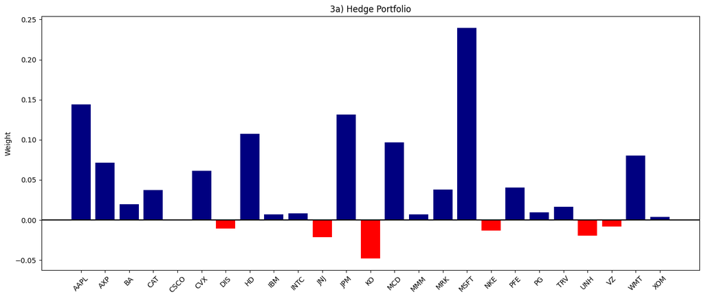

```
3a) HEDGE PORTFOLIO
Stock    Weight
 AAPL  0.144111
  AXP  0.071507
   BA  0.019666
  CAT  0.037442
 CSCO  0.000701
  CVX  0.061657
  DIS -0.010430
   HD  0.107247
  IBM  0.006841
 INTC  0.008391
  JNJ -0.021115
  JPM  0.131611
   KO -0.047924
  MCD  0.096443
  MMM  0.006828
  MRK  0.037837
 MSFT  0.239469
  NKE -0.013306
  PFE  0.040373
   PG  0.009353
  TRV  0.016809
  UNH -0.019450
   VZ -0.008362
  WMT  0.080542
  XOM  0.003756
```

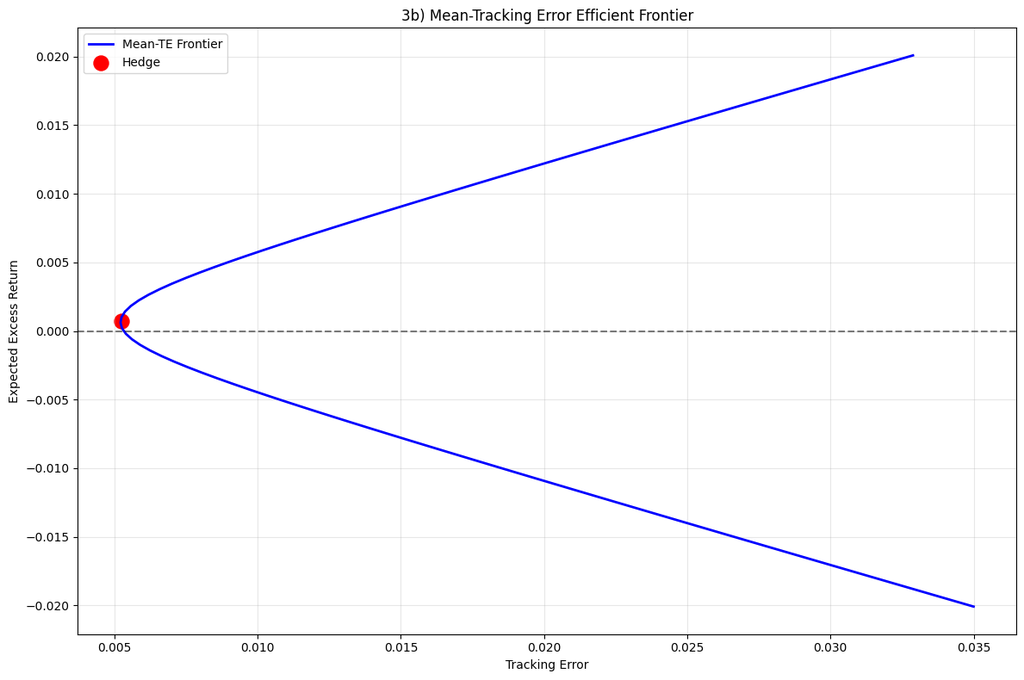

```
3c) Min TE: 0.00523824
3d) Excess Return: 0.00075154
```

```python
# Task 3
returns_window = gross_returns.iloc[-100:]
sp500_window = sp500_returns.iloc[-100:]
mu_stocks, mu_sp500 = returns_window.mean().values, sp500_window.mean()
Sigma = returns_window.cov().values
Sigma_L_R = np.array([returns_window.iloc[:, i].cov(sp500_window) for i in range(num_assets)])
var_sp500, R0 = sp500_window.var(), 1.0

w = cp.Variable(num_assets)
prob = cp.Problem(cp.Minimize(cp.quad_form(w, Sigma) - 2 * Sigma_L_R @ w), [cp.sum(w) == 1])
prob.solve()
w_hedge, mu_hedge = w.value, w.value @ mu_stocks
te_hedge, ex_hedge = np.sqrt(prob.value + var_sp500), mu_hedge - mu_sp500

plt.figure(figsize=(14, 6))
plt.bar(stock_names, w_hedge, color=['red' if x<0 else 'navy' for x in w_hedge])
plt.title('3a) Hedge Portfolio')
plt.ylabel('Weight')
plt.axhline(0, color='black')
plt.xticks(rotation=45)
plt.tight_layout()
plt.show()

print("\n3a) HEDGE PORTFOLIO")
print(pd.DataFrame({'Stock': stock_names, 'Weight': w_hedge}).to_string(index=False))

tes, exs = [], []
for mu_t in np.linspace(mu_sp500*0.98, mu_sp500*1.02, 100):
    w, w0 = cp.Variable(num_assets), cp.Variable()
    prob = cp.Problem(cp.Minimize(cp.quad_form(w, Sigma) - 2 * Sigma_L_R @ w),
                      [cp.sum(w) + w0 == 1, w @ mu_stocks + w0 * R0 == mu_t])
    try:
        prob.solve()
        if prob.status == cp.OPTIMAL:
            tes.append(np.sqrt(prob.value + var_sp500))
            exs.append(mu_t - mu_sp500)
    except:
        pass

plt.figure(figsize=(12, 8))
plt.plot(tes, exs, 'b-', linewidth=2, label='Mean-TE Frontier')
plt.scatter(te_hedge, ex_hedge, color='red', s=150, label='Hedge')
plt.axhline(0, color='black', linestyle='--', alpha=0.5)
plt.title('3b) Mean-Tracking Error Efficient Frontier')
plt.xlabel('Tracking Error')
plt.ylabel('Expected Excess Return')
plt.legend()
plt.grid(True, alpha=0.3)
plt.tight_layout()
plt.show()

print(f"\n3c) Min TE: {te_hedge:.8f}")
print(f"3d) Excess Return: {ex_hedge:.8f}")
```

### Task 4 André

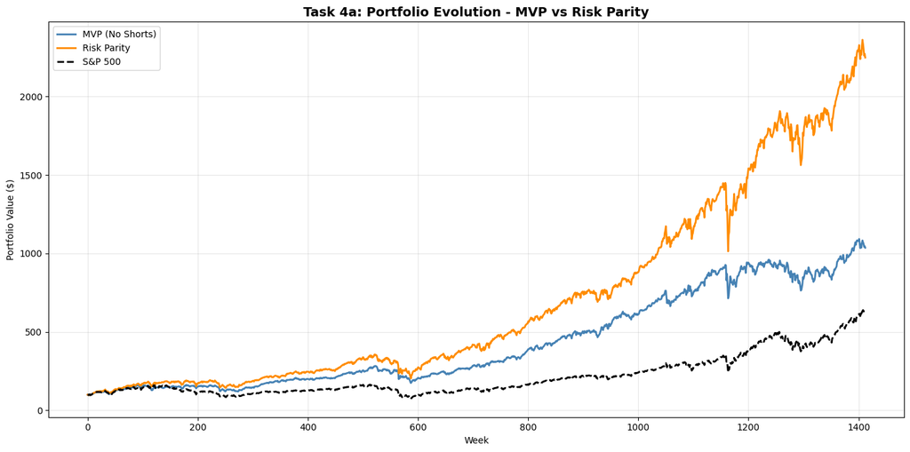

```
4b) PORTFOLIO VALUES EVERY 100 WEEKS
====================================================================================================
Week      MVP (No Shorts)               Risk Parity                   S&P 500
----------------------------------------------------------------------------------------------------
0         100.00                        100.00                        100.00
100       151.91                        168.82                        143.72
200       152.01                        173.51                        114.50
300       146.83                        186.77                        106.84
400       200.18                        246.29                        128.64
500       255.43                        338.81                        162.84
600       207.85                        274.45                        98.60
700       283.03                        416.75                        140.57
800       389.71                        567.36                        166.65
900       494.03                        744.29                        217.25
1000      613.20                        880.27                        240.97
1100      749.88                        1152.84                       272.32
1200      941.77                        1542.26                       388.00
1300      837.59                        1749.50                       395.49
1400      1083.20                       2301.30                       609.93

4c) PERFORMANCE METRICS
====================================================================================================
Metric                   MVP (No Shorts)                    Risk Parity
----------------------------------------------------------------------------------------------------
Final Value              1036.271830                        2248.084401
Annual Return            0.096625                           0.127644
Annual Volatility        0.143614                           0.159783
Sharpe Ratio             0.672807                           0.798862
Alpha vs S&P500          0.013421                           0.044441
Max Drawdown             -0.384571                          -0.428128
Avg ENC                  6.215652                           23.068900
```

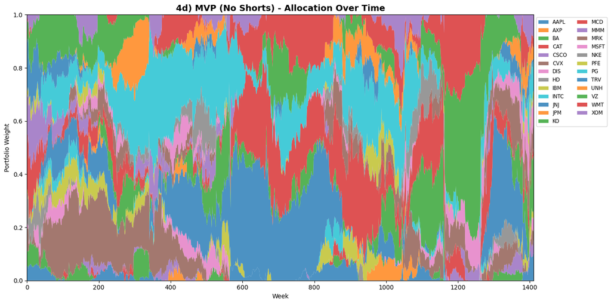

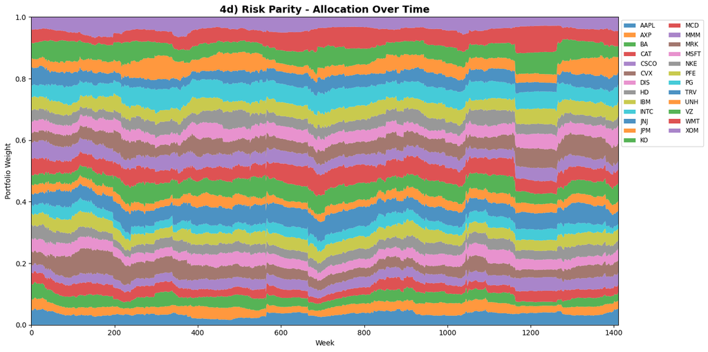

```python
def optimize_risk_parity(Sigma, max_iter=1000, tol=1e-8):
    n = Sigma.shape[0]
    w = np.ones(n) / n

    for iteration in range(max_iter):
        port_var = w @ Sigma @ w

        if port_var < 1e-12:
            break

        port_vol = np.sqrt(port_var)
        mrc = Sigma @ w
        rc = w * mrc
        rc = np.maximum(rc, 1e-12)
        target_rc = port_vol / n
        w_new = w * np.sqrt(target_rc / rc)
        w_new = np.clip(w_new, 1e-8, 0.5)
        w_new = w_new / w_new.sum()
        if np.max(np.abs(w_new - w)) < tol:
            break
        w = w_new
    w = np.clip(w, 0, 1)
    w = w / w.sum()

    return w

portfolios_task4 = {
    'MVP (No Shorts)': [100],
    'Risk Parity': [100]
}

weights_history_task4 = {
    'MVP (No Shorts)': [],
    'Risk Parity': []
}

for t in range(window, len(gross_returns)):

    returns_window = gross_returns.iloc[t-window:t]
    Sigma = returns_window.cov().values
    actual_returns = gross_returns.iloc[t].values

    weights = optimize_minimum_variance(Sigma, allow_shorts=False)
    if weights is None:
        weights = equal_weight_portfolio(num_assets)
    weights_history_task4['MVP (No Shorts)'].append(weights.copy())
    portfolio_return = weights @ actual_returns
    new_value = portfolios_task4['MVP (No Shorts)'][-1] * portfolio_return
    portfolios_task4['MVP (No Shorts)'].append(new_value)

    weights = optimize_risk_parity(Sigma)
    weights_history_task4['Risk Parity'].append(weights.copy())
    portfolio_return = weights @ actual_returns
    new_value = portfolios_task4['Risk Parity'][-1] * portfolio_return
    portfolios_task4['Risk Parity'].append(new_value)

plt.figure(figsize=(14, 7))
plt.plot(portfolios_task4['MVP (No Shorts)'], label='MVP (No Shorts)',
         linewidth=2, color='steelblue')
plt.plot(portfolios_task4['Risk Parity'], label='Risk Parity',
         linewidth=2, color='darkorange')
plt.plot(sp500_values, label='S&P 500', linewidth=2, linestyle='--', color='black')
plt.title('Task 4a: Portfolio Evolution - MVP vs Risk Parity',
          fontsize=14, fontweight='bold')
plt.xlabel('Week')
plt.ylabel('Portfolio Value ($)')
plt.legend()
plt.grid(True, alpha=0.3)
plt.tight_layout()
plt.show()

weeks = list(range(0, len(portfolios_task4['MVP (No Shorts)']), 100))
print("\n4b) PORTFOLIO VALUES EVERY 100 WEEKS")
print("=" * 100)
print(f"{'Week':<10}{'MVP (No Shorts)':<30}{'Risk Parity':<30}{'S&P 500':<20}")
print("-" * 100)
for week in weeks:
    print(f"{week:<10}"
          f"{portfolios_task4['MVP (No Shorts)'][week]:<30.2f}"
          f"{portfolios_task4['Risk Parity'][week]:<30.2f}"
          f"{sp500_values[week]:<20.2f}")

all_metrics_task4 = {}
for name in portfolios_task4.keys():
    all_metrics_task4[name] = calculate_metrics(portfolios_task4[name],
                                                 weights_history_task4[name])

print("\n4c) PERFORMANCE METRICS")
print("=" * 100)
header = f"{'Metric':<25}{'MVP (No Shorts)':<35}{'Risk Parity':<35}"
print(header)
print("-" * 100)

metric_names = ['Final Value', 'Annual Return', 'Annual Volatility',
                'Sharpe Ratio', 'Alpha vs S&P500', 'Max Drawdown', 'Avg ENC']
for metric in metric_names:
    row = f"{metric:<25}"
    for name in portfolios_task4.keys():
        value = all_metrics_task4[name][metric]
        if np.isnan(value):
            row += f"{'N/A':<35}"
        else:
            row += f"{value:<35.6f}"
    print(row)

weights_array_mvp = np.array(weights_history_task4['MVP (No Shorts)'])
plt.figure(figsize=(14, 7))
plt.stackplot(range(len(weights_array_mvp)), weights_array_mvp.T,
              labels=stock_names, alpha=0.8)
plt.title('4d) MVP (No Shorts) - Allocation Over Time',
          fontsize=14, fontweight='bold')
plt.xlabel('Week')
plt.ylabel('Portfolio Weight')
plt.legend(loc='upper left', bbox_to_anchor=(1, 1), ncol=2, fontsize='small')
plt.margins(0, 0)
plt.tight_layout()
plt.show()

weights_array_rp = np.array(weights_history_task4['Risk Parity'])
plt.figure(figsize=(14, 7))
plt.stackplot(range(len(weights_array_rp)), weights_array_rp.T,
              labels=stock_names, alpha=0.8)
plt.title('4d) Risk Parity - Allocation Over Time',
          fontsize=14, fontweight='bold')
plt.xlabel('Week')
plt.ylabel('Portfolio Weight')
plt.legend(loc='upper left', bbox_to_anchor=(1, 1), ncol=2, fontsize='small')
plt.margins(0, 0)
plt.tight_layout()
plt.show()
```

### Discussion Task 4:

Looking at the portfolio evolution plot and the final values we can see that the Risk Parity portfolio significantly outperforms the MVP portfolio with a final value of 2248 compared to 1036, we can also see that it has a higher sharpe ratio of almost 0.8 compared to 0.67. It also has a way higher diversification with ENC = 23.07 vs 6.22 from MVP indicating that it spreads out risk better across all of its assets over time.

Further if we look at the allocation plots we can see that the risk parity portfolio maintains a much smoother allocation across the plots over the backtest period whereas the MVP portfolio tends to heavily invest in a few number of stocks lowering its diversification and stability.